# Lab #7: Modeling With Statistics

Scott Burstein

10/10/2020

In this lab, we will practice making statistical models of data using R. Throughout the lab we’ll be using these models to understand how Spotify calculates their “popularity” scores assigned to each artist. This is a synthetic score that spotify assigns to each song based on some features of user data. We start on the premise that Spotify may consider some of the features in our dataset when creating the score.

Edit the Lab #7 markdown file (link to file) for your submission. Remember to change the “author” field above to your name. Send the markdown file (.Rmd) to your TA via direct message on Slack. Be sure to do the required reading!

Required reading:

R for Data Science: Modeling (Chapters 23-25) Optional reading:

Required Datasets: We will use the following datasets for the exercises.

artist_meta:` table of Grammy nominee names and some of their spotify metadata. Load the datasets and libraries. NOTE! It might be a good idea to convert the popularity column to a “double” type here to make later analyses easier. Do that here using the mutate and as.integer functions.

```r
library(tidyverse)
library(MASS)
load(url('https://dssoc.github.io/datasets/artist_meta.Rdata'))
artist_meta <- artist_meta %>% mutate(popularity=as.integer(popularity))
head(artist_meta)
```

```
## # A tibble: 6 x 6
##   artist   wikipedia_link       spotifyID   followers popularity genre
##   <chr>    <chr>                <chr>           <int>      <int> <chr>
## 1 Bon Iver https://en.wikipedi… 4LEiUm1SRb…   2546477         79 chamber pop,ea…
## 2 Billie … https://en.wikipedi… 6qqNVTkY8u…  20409690         99 electropop,pop
## 3 Ariana … https://en.wikipedi… 66CXWjxzNU…  42023952         95 dance pop,pop,…
## 4 H.E.R.   https://en.wikipedi… 3Y7RZ31TRP…   2150235         83 alternative r&…
## 5 Khalid   https://en.wikipedi… 6LuN9FCkKO…  10408465         96 alternative r&…
## 6 Lil Nas… https://en.wikipedi… 7jVv8c5Fj3…   2456187         86 country rap,lg…
```

```r
view(artist_meta)
```

#Exercises

1. In your own words, describe what statistical modeling means. When is it used? What does it allow data scientists to do?

**What are Statistical Models?**

Statistical models provide human interpretable information about data. Models are best when they provide insight about trends and patterns within the data, yet ignore data elements that are either erroneous or significantly distant from expected. This allows for a better understanding of the summary metrics by which the data can be best evaluated on.

Additionally, models can be either “predictive” or for “data discovery”. In other terms these two types are defined as “supervised” and “unsupervised”. Essentially, “predictive” or “supervised” models are used to make predictions about values that may not be present in the data set. “data discovery” or “supervised” are used to better understand the data given and to find patterns and trends within the set.

2. What is the correlation and statistical significance (measured by p-value) between an artist’s popularity and their number of followers on Spotify? Why would this correlation be less than 1.0?

Note: be sure you have converted the popularity column to numeric, as described above.

Hint: you may find the cor.test function helpful.

Prior to conducting a p-test, it is necessary to establish null and alternative hypotheses in order to understand what the p-value is actually revealing about the data.

$H_o:$ Artist’s popularity and number of followers on Spotify are independent.

$H_a:$ Artist’s popularity and number of followers on Spotify are not independent.

```r
cor.test(artist_meta$popularity, artist_meta$followers)
```

```
##
##  Pearson's product-moment correlation
##
## data:  artist_meta$popularity and artist_meta$followers
## t = 10.29, df = 139, p-value < 2.2e-16
## alternative hypothesis: true correlation is not equal to 0
## 95 percent confidence interval:
##  0.5522713 0.7421865
## sample estimates:
##       cor
## 0.6575509
```

```r
#correlation and statistical significance (p-value) are both in Pearson's corr.
```

The correlation between an artist’s popularity and their number of followers on Spotify is 0.658. This makes sense since the more popular an artist is on Spotify, the more people will likely follow them. In fact, I am somewhat surprised the correlation is not higher. This reveals that there are other factors, perhaps like Social Media presence or popularity on other platforms, that generate more Spotify followers for artists who may not actually have as many active listeners on Spotify.

The p-value is <2.2e-16, which is effectively 0. Typically, a p-value less than 0.05 is deemed statistically significant, as it is sufficient to reject the null hypothesis under this condition. It is important to note that this is NOT saying that the alternative hypothesis is true. Rather, there is only enough evidence to reject the null hypothesis. Hence, there is sufficient evidence to reject the notion that Artist’s popularity and number of followers on Spotify are independent variables.

3. Create a scatter plot showing the number of followers on the x-axis and artist popularity on the y-axis. Display a trend line on the plot. Can you draw any rough quantitative information about the relationship between these two variables just from this plot?

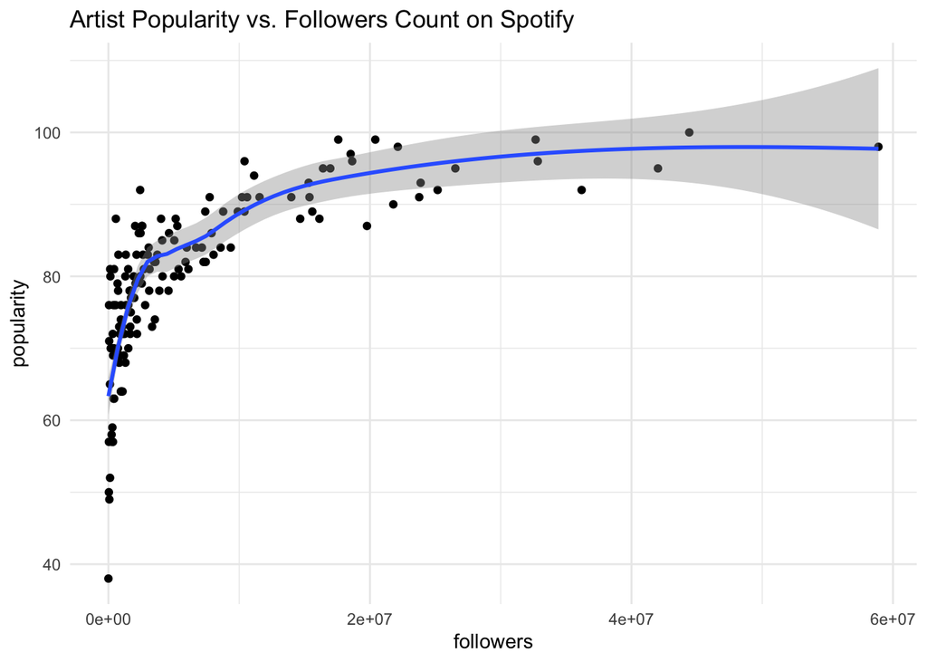

```r
pop_plot <- ggplot(data = artist_meta,
                   aes(x = followers, y = popularity)) +
  geom_point() +
  geom_smooth() +
  theme_minimal() +
  labs(title = "Artist Popularity vs. Followers Count on Spotify")

pop_plot
```

```r
#When method and formula left empty,
#`geom_smooth()` using method = 'loess' and formula 'y ~ x'
```

4. Generate a new column of logical type called is_pop to indicate whether a given artist is categorized in any pop genre (e.g. any genre that includes the word “pop”, like “rap pop”, etc). Create another column named is_rap that indicates whether the artist has been included in any “rap” genre. Make summary statistics indicating how many artists fall into either category.

**Instantiate is_pop variable:**

```r
artist_meta <- artist_meta %>%
  mutate(is_pop = grepl('pop', genre, fixed=TRUE)) %>%
  mutate(is_pop = ifelse(is_pop, 'pop', 'not pop')) %>%
  mutate(is_pop = as.factor(is_pop))
```

**Instantiate is_rap variable:**

```r
artist_meta <- artist_meta %>%
  mutate(is_rap = grepl('rap', genre, fixed=TRUE)) %>%
  mutate(is_rap = ifelse(is_rap, 'rap', 'not rap')) %>%
  mutate(is_rap = as.factor(is_rap))
```

**View new columns:**

```r
artist_meta
```

```
## # A tibble: 141 x 8
##    artist  wikipedia_link   spotifyID followers popularity genre   is_pop is_rap
##    <chr>   <chr>            <chr>         <int>      <int> <chr>   <fct>  <fct>
##  1 Bon Iv… https://en.wiki… 4LEiUm1S…   2546477         79 chambe… pop    not r…
##  2 Billie… https://en.wiki… 6qqNVTkY…  20409690         99 electr… pop    not r…
##  3 Ariana… https://en.wiki… 66CXWjxz…  42023952         95 dance … pop    not r…
##  4 H.E.R.  https://en.wiki… 3Y7RZ31T…   2150235         83 altern… pop    rap
##  5 Khalid  https://en.wiki… 6LuN9FCk…  10408465         96 altern… pop    not r…
##  6 Lil Na… https://en.wiki… 7jVv8c5F…   2456187         86 countr… pop    rap
##  7 Lizzo   https://en.wiki… 56oDRnqb…   2043223         87 escape… pop    rap
##  8 Post M… https://en.wiki… 246dkjvS…  22131044         98 dfw ra… not p… rap
##  9 Lana D… https://en.wiki… 00FQb4jT…   9891782         89 art po… pop    not r…
## 10 Vampir… https://en.wiki… 5BvJzeQp…   1522817         76 baroqu… pop    not r…
## # … with 131 more rows
```

**Pop Count:**

```r
pop_count <- artist_meta %>%
  count(is_pop)
pop_count
```

```
## # A tibble: 2 x 2
##   is_pop      n
##   <fct>   <int>
## 1 not pop    44
## 2 pop        97
```

**Rap Count:**

```r
rap_count <- artist_meta %>%
  count(is_rap)
rap_count
```

```
## # A tibble: 2 x 2
##   is_rap      n
##   <fct>   <int>
## 1 not rap   110
## 2 rap        31
```

5. First compute a measure of the relationship (you may use correlations or chi-squared tests here) between the is_pop and is_rap variables. Then compute the relationships with each of those two variables and Spotify’s popularity metric. Which relationships are statistically significant? What does that tell us about Spotify’s measure of popularity?

Note: you should end up with three models - one for each pairwise similarity test.

### Chi-squared test for independence:

$$\chi^2 = \sum \frac {(O - E)^2}{E}$$

Chi-squared value reveals the extent to which two data sets are unique. A low value indicates strong correlation between the two sets.

Conversely, a high chi-squared value indicates minimal correlation between the two sets.

The degrees of freedom (df) refers to the number of independent variables which affect the variables of interest in a given data set.

### For All Three Models:

#### (pop - rap | pop - popularity | rap - popularity)

$H_o:$ The two variables are independent.

$H_a:$ The two variables are not independent.

```r
chisq.test(artist_meta$is_pop, artist_meta$is_rap)
```

```
##
##  Pearson's Chi-squared test with Yates' continuity correction
##
## data:  artist_meta$is_pop and artist_meta$is_rap
## X-squared = 0.91013, df = 1, p-value = 0.3401
```

This is a low X-squared value (0.91013), meaning there is some correlation between `is_pop` and `is_rap`. The p-value (0.3401) is too large though to reject the null hypothesis of no correlation.

```r
chisq.test(artist_meta$is_pop, artist_meta$popularity)
```

```
##
##  Pearson's Chi-squared test
##
## data:  artist_meta$is_pop and artist_meta$popularity
## X-squared = 45.852, df = 42, p-value = 0.3155
```

This is a high X-squared value (45.852), meaning there is not a strong correlation between `is_pop` and `popularity`. The p-value (0.316) is too large to reject the null hypothesis of no correlation.

Hence, it is improbable that a correlation exists between `pop` and `popularity` of a song.

```r
chisq.test(artist_meta$is_rap, artist_meta$popularity)
```

```
##
##  Pearson's Chi-squared test
##
## data:  artist_meta$is_rap and artist_meta$popularity
## X-squared = 42.955, df = 42, p-value = 0.4301
```

This is a high X-squared value (42.955), meaning there is not a strong correlation between `is_rap` and `popularity`. The p-value (0.4301) is too large to reject the null hypothesis of no correlation.

Hence, it is improbable that a correlation exists between `rap` and `popularity` of a song.

### Important Notes for Q5:

Was unable to produce cor() or cor.test() products because could not convert `is_pop` or `is_rap` to numeric type. Error was the following: “‘x’ must be a numeric vector” - where x was the `is_pop` or `is_rap` count.

Also, the three chi-squared tests all yielded “Chi-squared approximation may be incorrect” warnings, which are concerning yet not problematic for the scope of this analysis.

Furthermore, I find it unlikely that all three of these models yielded no correlation. Perhaps the chi-squared approximation errors were in fact valid, and my analysis is flawed. There **should** be a correlation between these variables, as certain genres of music, such as pop and rap, are inherently more popular than others.

6. Use ggplot to create box plots or violin plots showing the popularity by is_pop and is_rap. What can you say about the data from these plots?

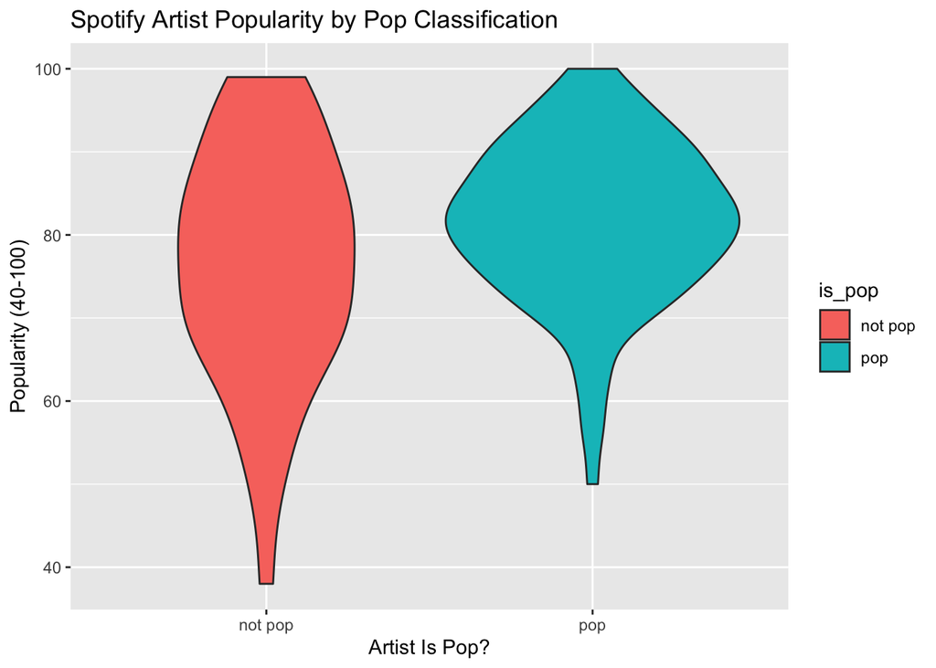

```r
pop_violin_plot <- ggplot(data = artist_meta,
                      aes(x = is_pop, y = popularity, fill = is_pop)) +
  geom_violin() +
  labs(title = "Spotify Artist Popularity by Pop Classification",
       x = "Artist Is Pop?",
       y = "Popularity (40-100)")
pop_violin_plot
```

Based on this violin plot, it is evident that artists classified as `pop` have higher Popularity on average than `not pop` artists.

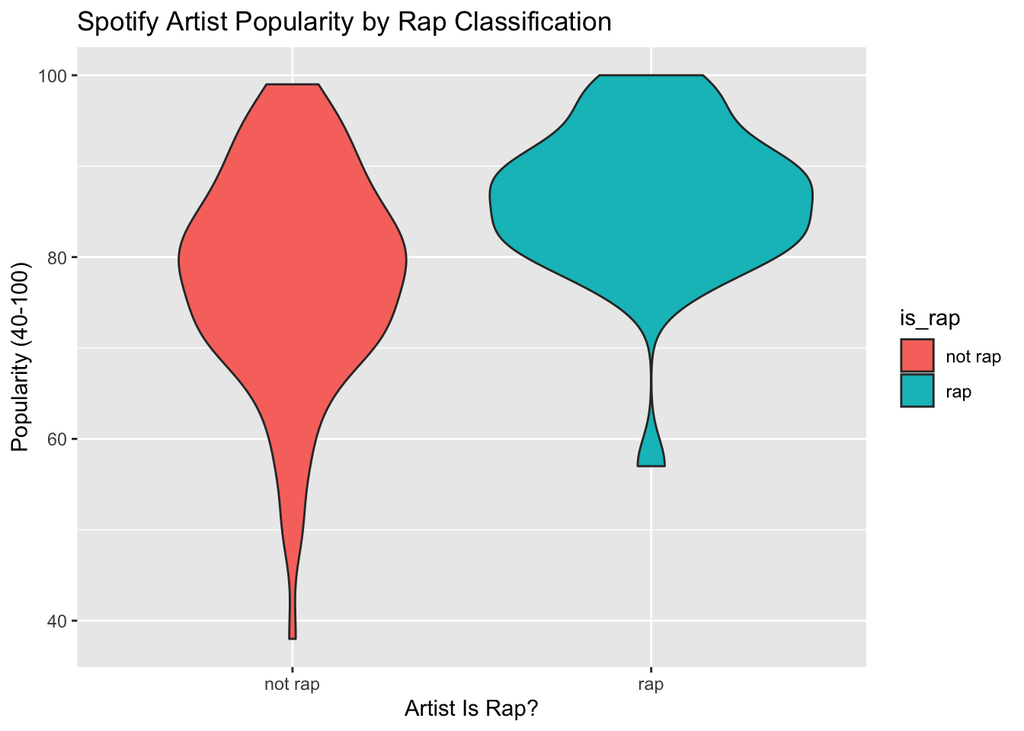

```r
rap_violin_plot <- ggplot(data = artist_meta,
                      aes(x = is_rap, y = popularity, fill = is_rap)) +
  geom_violin() +
  labs(title = "Spotify Artist Popularity by Rap Classification",
       x = "Artist Is Rap?",
       y = "Popularity (40-100)")
rap_violin_plot
```

Based on this violin plot, it is evident that artists classified as `rap` have higher Popularity on average than `not rap` artists.

Compared to the *Spotify Artist Popularity by Pop Classification*, the *Spotify Artist Popularity by Rap Classification* reveals that the `not rap` artists have a tighter distribution around a Popularity mean of 80, whereas the `not pop` distribution in the former plot was more spread out. This potentially indicates that the artists deemed as `not rap` are more likely to also be `pop` or other genres that are also popular.

On the other hand though, the `rap` violin plot has a tight distribution around 87, indicating that most rap artists are popular, even moreso than `pop` artists.

7. Create a multivariate linear model (see the lm function) predicting the Spotify popularity measure from both is_pop and is_rap. Then create a second model that additionally includes the artist’s number of followers as a covariate. What do these models tell us? Why would we create a second model that includes the additional variable?